# 1. Estadística Descriptiva

## 1. Introducción a la Estadística

La estadística estudia **fenómenos aleatorios** que son aqeullos que, incluso en las mismas condiciones, pueden dar lugar a diferentes resultados.

Con la **Estadística Descriptiva** aprendemos a describir los resultados de los fenómenos aleatorios y con la **Inferencia Estadística** aprenderemos a entenderlos y predecirlos, midiendo y controlando nuestros posibles errores en términos de **Probabilidades**.

#### Población e individuo

El conjunto de todos los individuos recibe el nombre de **población**. Croterios de inclusión y exclusión que definen el conjunto poblacional. Al conjunto de individuos que elegimos de la población lo denominaremos muestra. Habitualmente la muestra representativa se obtendrá por un procedimiento aleatorio (es decir, al azar) lo cual permitirá medir y controlar los posibles erroren en términos de probabilidades. Lo importante, mas que la aleatoriedad, es la representatividad de la muestra.

Debe evitarse el sesgo de selección. Se busca la aleatoriedad en el muestreo, para lo que existen diferentes métodos estadísticos.

#### Variable aleatoria y modelo probabilístico

Las caracterísitcas de estudio se denominan **variable aleatoria X**. Sobre esta variable deseamos realizar inferencia estaídstica (estimación puntual, intervalos de confianza o pruebas de hipótesis), para lo cual se selecciona al azar una muestra de tamaño *n* en los que se observará la variable de estudio.

Así, tendrémos *n* realizaciones de la variable aleatoria en estudio *X*, que representamos por $(x_1 , x_2 ,..., x_n)$ entendiéndose cada $x_i , i = 1, ..., n$ como el valor que toma la variable de estudio en le individuo seleccionado al azar en el *i-ésimo* lugar.

Se considerarán solamente los casos en los que cada invididuo es seleccionado independiente e idéntitica a como lo son los demás, esto es,la muestra es **independiente e idénticamente distribuida (IDD)**, lo que quiere decir que (1) los elementos muestrales son todos eventos independientes, y, (2) todos los elementos de la muestra son tomados de la misma distribución de porbabilida.

Los valores posibles de cada variable aleatoria junto con las probabilidades con los que los toma, se denomina distribución o ley de probabilidad de la variable aleatoria en estudio, o mas brevemente **modelo probabilístico**. Habitualmente se supondrá un modelo probabilístico que creemos refleja el fenómeno aleatorio que se está estudiando, obteniendo una simplificación de este, permitiendonos operar métodos matemáticos para la realización de inferencias.

> En la Estadística Descriptiva no se hacen suposiciones extrañas a los datos, como puede ser la de un modelo probabilístico poblacional: se deja que los datos *hablen por sí mismos*. Por el contrario, las técnicas de la Inferencia Estadística requerirán de suposiciones ajenas a los datos (simetría en la distribución modelo, población noraml, etcétera) (p. 42)

## 2. Conceptos fundamentales de la Estadística descriptiva

Los individuos de una población poseen caracteres o características. Estos pueden ser cuantitativos (su observación se asocia a un valor numérico) o cualitativos (su valor se asocia a una clase determinada). Es habitual denominar a los caracteres variables estadísticas o simplemente variables.

Los tipos o clases que pueden presentar los caracteres las denominamos *modalidades*, las cuales deben ser mutuamente excluyentes (disjuntas) y colectivamente exhaustivas.

La información generalmente se organiza en una *Matriz de datos*

| Individuo | Carácter 1 | Carácter 2 | … | Carácter p |
| --- | --- | --- | --- | --- |
| Individuo 1 | Dato 1.1 | Dato 1.2 | … | Dato 1.p |
| Individuo 2 | Dato 2.1 | Dato 2.2 | … | Dato 2.p |
| … | … | … | … | … |
| Individuo n | Dato n.1 | Dato n.2 | … | Dato n.p |

Un ejemplo lo vemos en el famóso conjunto de datos iris

```r
head(iris)
```

```
##   Sepal.Length Sepal.Width Petal.Length Petal.Width Species
## 1          5.1         3.5          1.4         0.2  setosa
## 2          4.9         3.0          1.4         0.2  setosa
## 3          4.7         3.2          1.3         0.2  setosa
## 4          4.6         3.1          1.5         0.2  setosa
## 5          5.0         3.6          1.4         0.2  setosa
## 6          5.4         3.9          1.7         0.4  setosa
```

## Agrupamiento por intervalos

Definamos los intervalos o *clases* como:

$$[c_0 - c_1),[c_1 - c_2),...,[c_{j-1} -
c_j)$$
En donde los extremos de la clases j-ésima son $c_{j-1}$ y $c_j$; la amplitud del intervalos será la diferencia de sus extremos; centro o marca de clase el punto medio del intervalo, al caso $c'_{j}=(c_{j} + c_{j-1})/2$.

Como regla general podemos contruir intervalos de amplitud constante, $k$, el propuesto por Sturges (1962)

$$k = 1 + 3.322log_{10}n$$

```r
# Calcular el número de intervalos según la regla de Sturges (logaritmo base 10)
n <- length(mtcars$mpg)
k <- ceiling(1 + 3.322 * log10(n))

# Crear los intervalos
breaks <- pretty(range(mtcars$mpg), n = k)
intervals <- cut(mtcars$mpg, breaks, right = FALSE)

# Calcular las frecuencias
freq_table <- table(intervals)

# Mostrar la tabla de frecuencias
print(freq_table)
```

```
## intervals
## [10,15) [15,20) [20,25) [25,30) [30,35)
##       5      13       8       2       4
```

## Distribuciones unidimensionales de frecuencia

- **Frecuencia total:** número de datos *n*.
- **Frecuencia absoluta** $n_i$ de la modalidad $M_i$:

$$\sum_{i=1}^k n_{i} = n_1 + n_2 + ... +
n_k = n$$
- **Frecuencia relativa f_i:**

$$f_{i} = \frac{n_i}{n}$$
Por lo que se puede verificar facilmente que:

$$\sum_{i=1}^k f_{i} = f_1 + f_2 + ... +
f_k = 1$$
- **Frecuencua absoluta acumulada** $N_i$:

$$N_{i} = n_{1} + ... + n_{i} =
\sum_{j=1}^i n_j$$
- **Frecuencua absoluta acumulada** $F_i$: Se define $f_i$

$$F_{i} = f_{1} + ... + f_{i} =
\sum_{j=1}^i f_j$$

```r
freq <- cbind(freq_table, round(freq_table / n,2), cumsum(freq_table), round(cumsum(freq_table / n),2))

colnames(freq) <- c('ni','fi','Ni','Fi')
freq
```

```
##         ni   fi Ni   Fi
## [10,15)  5 0.16  5 0.16
## [15,20) 13 0.41 18 0.56
## [20,25)  8 0.25 26 0.81
## [25,30)  2 0.06 28 0.88
## [30,35)  4 0.12 32 1.00
```

## Representaciones gráficas de las distribuciones unidimensionals de frecuencias

### Variables cualitativas

#### **Gráfico de sectores**

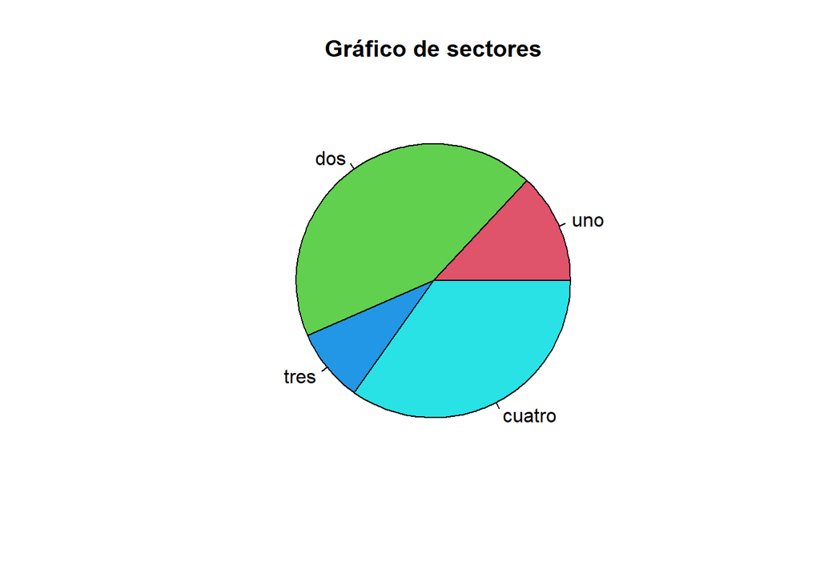

```r
set.seed(123)
x2 <- sample(10,size = 4)
n2 <- c('uno','dos','tres','cuatro')
c2 <- c(2:5)

pie(x2,labels = n2,col = c2,main = 'Gráfico de sectores')
```

#### **Gráfico de barras**

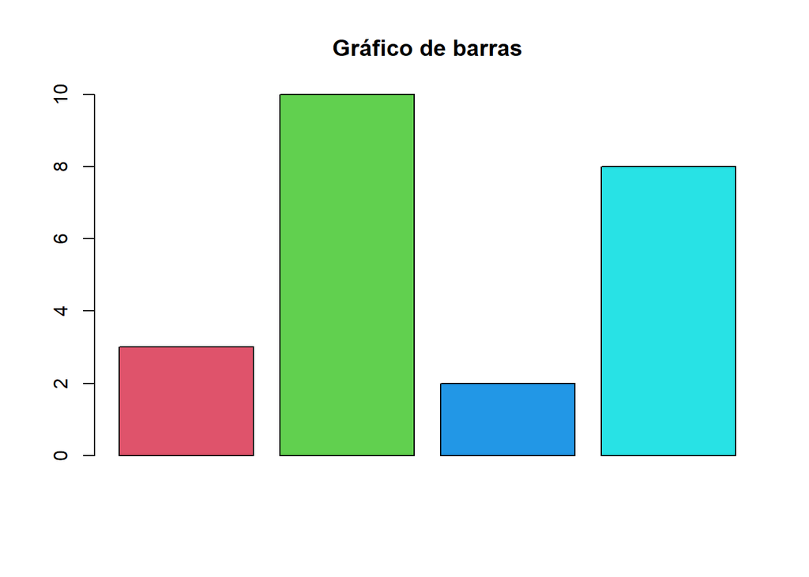

```r
barplot(x2,col = c2,main = 'Gráfico de barras')
```

### Variables cuantitativas

#### **Histográmas**

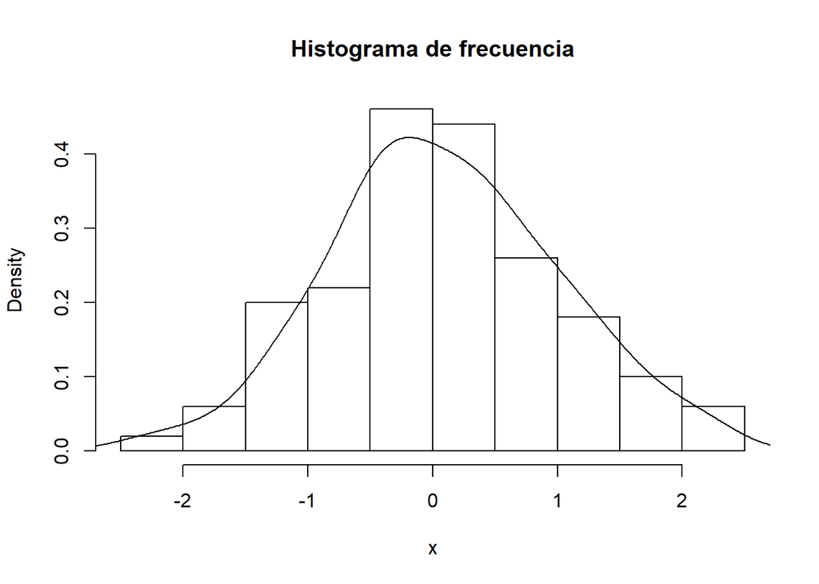

```r
set.seed(123)
x <- rnorm(100)
hist(x, main = 'Histograma de frecuencia', freq = F, col= 'white')
lines(density(x))
```

#### **Diagrama de hojas y ramas**

*steam and leaft plot* fue inventado por Tukey (1977). Es especialmente útil para datos pequeños a medianos y proporciona una manera rápida de ver la distribución de los datos, similar a un histograma pero más simplificado y manual.

```r
stem(x)
```

```
##
##   The decimal point is at the |
##
##   -2 | 30
##   -1 | 75
##   -1 | 3321111000
##   -0 | 77777666665555
##   -0 | 44443333322222211100
##    0 | 01111122223334444444
##    0 | 55566677888999
##    1 | 0001122344
##    1 | 55678
##    2 | 122
```

#### Función de distribución empírica

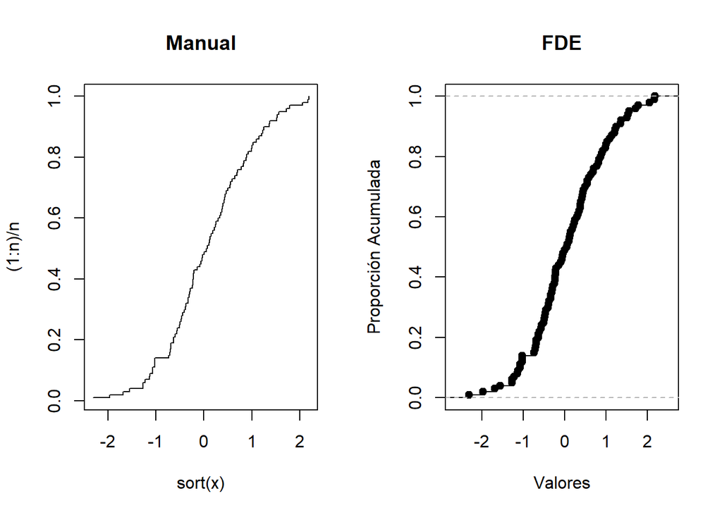

```r
par(mfrow = c(1,2))

n <- length(x)
plot(sort(x), (1:n)/n,type = 's', main = 'Manual')

# Forma 2

ecdf_data <- ecdf(x)

# Graficar el ECDF
plot(ecdf_data, main = 'FDE',
     xlab = "Valores", ylab = "Proporción Acumulada")
```

## Medidas de tendencia central

**Media aritmética:**

Dada una variable $X$ con un conjunto $n$ de observaciones $(x_{1},x_{2},...,x_{n})$ y $n_{i}$ la frecuencia absoluta, definimos la media aritmética:

$$\mu = \frac{\sum_{i=1}^k
x_{i}n_{i}}{n}$$

Para datos sin agrupar, esto es con $n_{i} = 1$, podemos definir la media

$$\mu = \frac{1}{n} \sum_{i=1}^n
x_{i}$$
**Mediana:**

La mediana se define como aquel valor de la variable tal que, supuestos ordenados los valores de ésta en orden creciente, la mitad son menores o iguales y la otra mitad mayores o iguales.

La podemos definir como sigue:

$$M_{e} =
\begin{cases}
x_{\left(\frac{n+1}{2}\right)} & \text{si } n \text{ es impar}
\\[10pt]
\frac{x_{\left(\frac{n}{2}\right)} + x_{\left(\frac{n}{2} +
1\right)}}{2} & \text{si } n \text{ es par}
\end{cases}$$
**Moda:** La moda se define como aquel valor d ela variable al que corresponde máxima frecuencia (absoluta o relativa)

Imaginemos un vector aleatorio

```r
set.seed(123)

x <- sample(100,size = 100, replace = T)
'Media:'; mean(x)
```

```
## [1] "Media:"
```

```
## [1] 52.15
```

```r
'Mediana:'; median(x)
```

```
## [1] "Mediana:"
```

```
## [1] 50
```

```r
# Creamos la función moda
mode <- function(x) {
  ux <- unique(x)
  ux[which.max(table(match(x, ux)))]
}

'Moda:'; mode(x)
```

```
## [1] "Moda:"
```

```
## [1] 25
```

## Medidas de localización

**Cuantiles:**

El cuantil $p_{r/k},r = 1,2,...,k-1$ se define como aquel valor de la variable que divide la distribución de frecuencias, previamente ordenada de forma creciente, en dos partes, estando el $(100*r/k)%$ de ésta formado por valores menores que $p_{r/k}$.

Si $k=4$ los cuantiles reciben el nombre de *cuartiles*. Si $k=10$ los cuantiles reciben el nombre de *deciles*. Si $k=100$ los cuantiles reciben el nombre de *centiles*.

La mediana $M_e$ es el segundo cuartil, o el quinto decil, etc. Su cálculo depende de si están o no agrupados los datos:

Datos sin agrupar

$$N_{j-1}<\frac{r}{k}n<N_{j}$$
El $e-ésimo$ cuantil de orden $k$ será $p_{r/k} = c_{j}$, valor al que corresponde la frecuencia absoluta acumulada de $N_{j}$.

El cálculo de los cuartiles se puede hacer con la función *quantile*:

```r
print('Cuartiles:')
```

```
## [1] "Cuartiles:"
```

```r
quantile(x)
```

```
##    0%   25%   50%   75%  100%
##  4.00 26.75 50.00 79.50 99.00
```

Los cuartiles nos permiten construir los Diagramas de caja o Box-plot, creados por Tukey (1977).

El Box-plot representa una caja donde el lado inferir es el primer cuartil, el superiro el tercer cuartil. La caja aparece dividida por el segundo cuartil, o mediana. Finalmente, los “bigotes” representan siguen la regla de Tukey de 1.5IQR - Q1 y 1.5IQR + Q3. Los datos por fuera de estas referencias se conocen como datos atípicos o *outliers*.

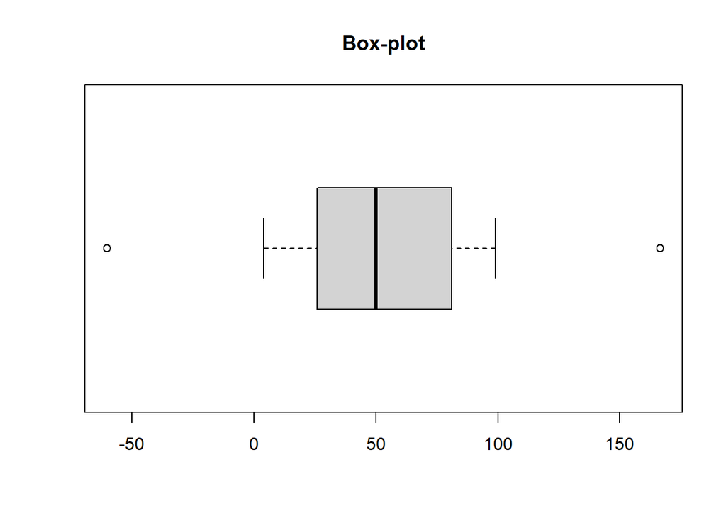

```r
# Agreguemos datos atípicos

x <- c(x,quantile(x,probs = .75)+1.65*IQR(x),
       quantile(x,probs = .25)-1.65*IQR(x))

# Grafiquemoslo
boxplot(x,horizontal = T, main = "Box-plot")
```

**Rango intercuartílico:**

El rango intercuartílico, o IQR, se define como la diferencia entre el primer cuartil (percentil 25) y el tercer cuartil (percentil 75). El 50% de datos centrales.

```r
quantile(x,probs = .75) - quantile(x,probs = .25)
```

```
##   75%
## 54.25
```

```r
IQR(x)
```

```
## [1] 54.25
```